# STAT/MATH 495: Problem Set 05

Jonathan Che, Tim Lee, Sarah Teichman

2017-10-11

## Variable Cleanup

First, we need to do some simple cleanup of the variables in the data.

The distribution of count is heavily right skewed. A log transformation somewhat overcorrects for this and creates a distribution that is slightly skewed to the left. Though we will use log(count) as our response variable when modeling, we will do EDA on untransformed counts just so that we can see the full variation in our data.

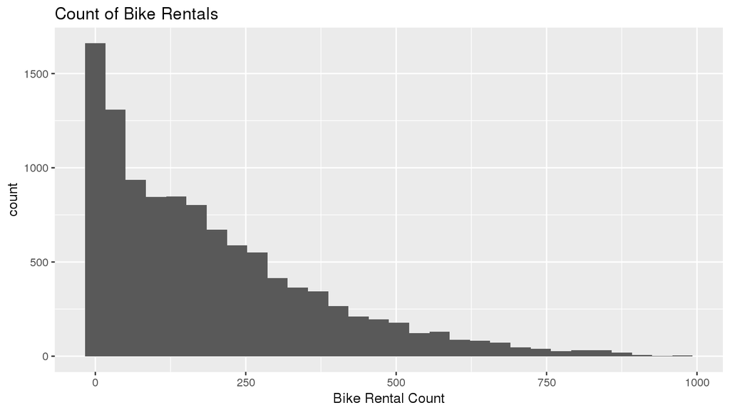

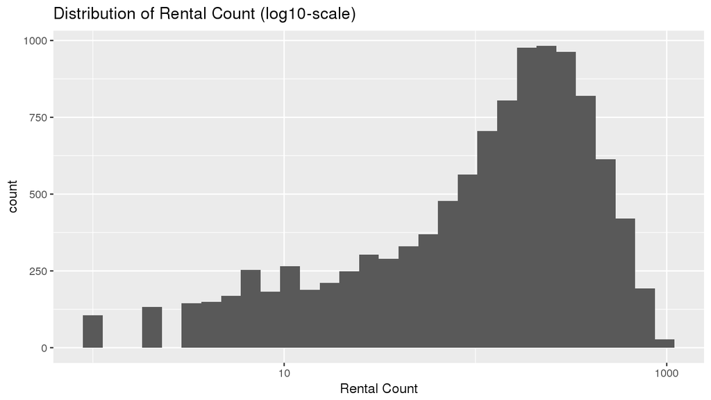

We also pull out datetime information and change categorical variables into factors.

## Exploratory Data Analysis

Intuitively, there are a few major factors that we think would significantly influence the number of bikes rented per hour. We could generally group these factors into two categories: time-based factors (e.g. time of day/week/year), and condition-based factors (e.g. weather, holidays, etc.).

We begin by examining some potential time-based factors.

### Time-Based Factors

We first look at the average number of bike rentals per hour of day (note: the below plot looks similar when using the median, so we can be relatively confident that it’s not too affected by extreme values).

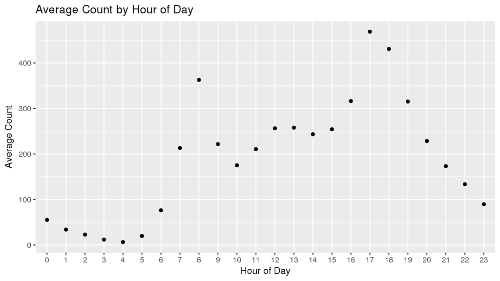

Clearly, there is significant variation in bike rentals over the course of a given day. We notice that rush hours (~8AM and 5-6PM) experience significant spikes in bike rentals, which suggests that a large portion of bike-share users may rent bikes to get to work. Thus, hour of day seems like it would be an important variable for a model to use.

Importantly, we notice that the relationship between hour of day and average number of bikes rented is nonlinear. As such, when we model, we consider `hour of day` as a categorical variable with 24 levels, rather than a numeric variable. This change gives our linear regression model more flexibility to capture nonlinear average relationships between `hour of day` and `count`.

Next, we look at a similar plot for the average number of bike rentals per month.

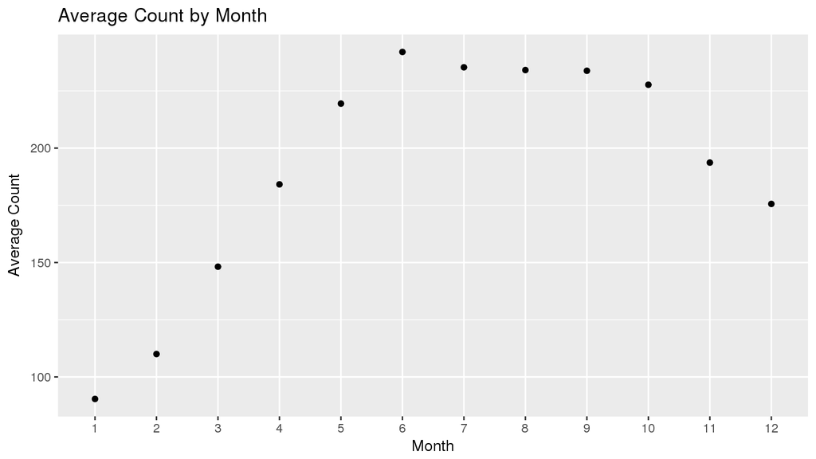

Here, we notice that there are typically more bike rentals in the summer and fall than during the winter, as expected. Again, this trend is generally nonlinear so we want to consider `month` as a categorical variable.

To see if there are significant interactions between hour of day and month of year, we examine the following plot:

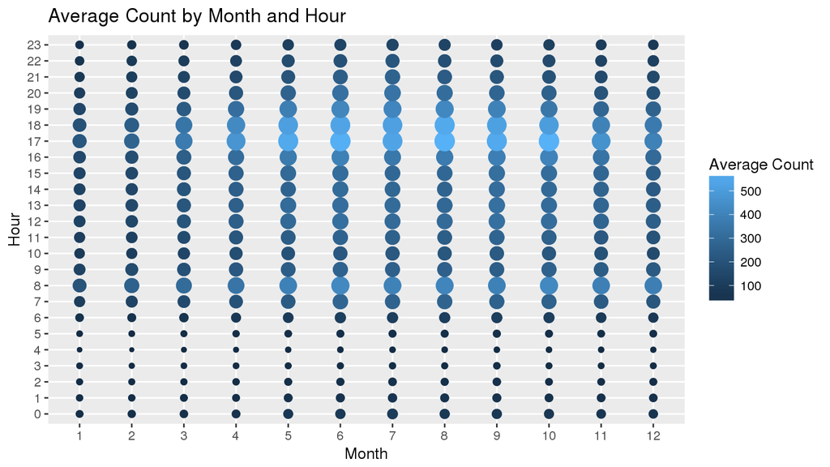

We notice that in the summer months, days are longer, so there are more bike rentals early in the day and late at night. Though these trends are interesting, we will simply note them and move on for now, given the limits we have on the number of predictors we can use.

### Condition-Based Factors

First, we look at the relationships between holidays/working days and average bike rentals.

holiday/working interaction, 2 variables, not worth it.

```r
# Holiday vs. Non-holiday Counts
train_m %>%
  group_by(holiday, workingday) %>%
  summarize(rentals_per_day=mean(count))
```

| holiday | workingday | rentals_per_day |
| --- | --- | --- |
| 0 | 0 | 189 |
| 0 | 1 | 193 |
| 1 | 0 | 186 |

We notice that there are the fewest average number of rentals per day on holidays, more on nonholiday weekends, and the most on nonholiday weekdays. This finding matches our earlier observations about rush hour, where we stated that many bike rentals seem to be used for getting to/from work.

Since the magnitudes of these differences are relatively small (and we only have 3 variables to use in our model), we will again simply note these findings and move on.

More than 65% of the observations are for weather 1, more than 25% for weather 2, about 8% for weather 3 and less than 1% for weather 4.

| weather | num | count |
| --- | --- | --- |
| 1 | 7192 | 205 |
| 2 | 2834 | 179 |
| 3 | 859 | 119 |
| 4 | 1 | 164 |

We see that in general, good weather (`weather == 1`) is associated with more bike rentals, on average.

When considering the final 3 variables that we wish to use for our model, however, we need to think about their collinearities. We want to use 3 variables that capture as much of the total variation in the data as possible. While, for example, two different variables may seem like good predictors on their own, they may be so heavily correlated with each other that using both of them may not significantly improve a linear regression model’s results.

In general, we know that the weather information provided (e.g. temperature, humidity, etc.) is heavily correlated with the month of the year, as seen below.

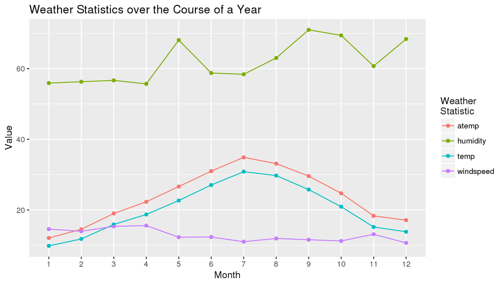

Ignoring for a moment the general amorphousness of the y-axis units, we notice that the month of the year can generally capture some of the variation in the different weather statistics over the course of a year.

As such, we use the `weather` categorical variable along with `month` and `hour` in our final linear regression model.

# Fit model & Create submission

```r
submissionModel <- lm(log_count ~ dt_month + dt_hour + weather, data = train_m)
preds <- predict.lm(submissionModel, test)
submission <- data.frame(test$datetime, exp(preds))
names(submission) <- c("datetime", "count")
write.csv(submission, "submission.csv", row.names=FALSE)
```